# Within-person event-study & difference-in-differences with **vivainsights** in R

2026-07-01

# Measuring behaviour change with an event-study / difference-in-differences

## Introduction

A common question in Copilot Analytics is *causal*: **did a person’s collaboration behaviour actually change after they started using Copilot**, or are heavy users simply different people to begin with? A plain comparison of users vs non-users cannot separate the two, because adoption is not random.

A **within-person event-study** paired with a **two-way fixed-effects (TWFE) difference-in-differences (DiD)** model is a standard way to address this. The design:

- aligns every adopter on their own **event time** (weeks relative to the week they adopted Copilot),
- compares adopters against a control group of non-adopters over the same calendar weeks,
- absorbs each person’s baseline (**person fixed effects**) and every calendar week’s common shocks (**week fixed effects**), and
- reads the treatment effect as the *within-person* change in the treated group relative to the control group.

Person Query exports do not ship with a clean adoption event, so this notebook builds a **small seeded simulation** whose column names match a real Person Query. The downstream modelling code therefore runs on a real export loaded with `vivainsights::import_query()`, so you swap out the data-generation chunk and map your outcome columns (shown below). The simulation injects a **clearly-labelled illustrative effect** so the model has something to recover; this is for demonstration only and is not a real result.

## Set-up

This example uses **fixest** for fast fixed-effects estimation; install it with `install.packages("fixest")` if you do not already have it.

```r
knitr::opts_chunk$set(warning = FALSE, message = FALSE)
library(dplyr)
library(tidyr)
library(ggplot2)
library(scales)
library(fixest)   # fast fixed-effects estimation (feols, i(), iplot)
```

To run this notebook on your **own** export instead of the simulation, replace the simulation chunk below with the following, then continue unchanged from the *“Derive the adoption week”* section:

```r
panel <- vivainsights::import_query("your-person-query.csv")
app_cols <- grep("^Copilot_actions_taken_in", names(panel), value = TRUE)
panel <- panel %>%
  mutate(across(all_of(app_cols), ~ tidyr::replace_na(.x, 0))) %>%
  mutate(Total_Copilot_actions_taken = rowSums(across(all_of(app_cols))))
# choose the outcome column(s) to model, e.g. Collaboration_hours, Chat_hours,
# Emails_sent -- these are standard Person Query columns.
```

## Simulate a Person-Query-shaped panel

The block below creates a weekly panel with the same shape as a Person Query: one row per `PersonId` x `MetricDate`, a `Total_Copilot_actions_taken` column, and a few collaboration outcomes (`Collaboration_hours`, `Chat_hours`, `Emails_sent`). Treated people adopt Copilot at a **staggered** week; control people never adopt. We add person baselines, calendar-week seasonality, and noise so the panel looks realistic.

> **Replace this chunk for real data.** Load your export with `vivainsights::import_query()` and derive the adoption week from the first week of non-zero Copilot actions (see the next section). Everything downstream stays the same.

```r
set.seed(100)

n_persons <- 400L
n_weeks   <- 40L
weeks     <- seq(as.Date("2024-01-01"), by = "week", length.out = n_weeks)

# ---- clearly-labelled illustrative effect ---------------------------------
# DEMO ONLY: this is the size of the behaviour change we inject into treated
# people after adoption. Set to 0 (or delete) when running on real data, so the
# model should estimate the effect, not have it baked in.
TREATMENT_EFFECT <- 0.8   # extra collaboration hours/week once adopted
# ---------------------------------------------------------------------------

persons <- tibble(
  PersonId    = sprintf("P%04d", seq_len(n_persons)),
  treated     = rbinom(n_persons, 1, 0.6),
  # person baseline (some people simply collaborate more than others)
  base_collab = rnorm(n_persons, mean = 12, sd = 3)
)

# Treated people adopt at a staggered week (10..28); controls never adopt.
persons <- persons %>%
  mutate(adopt_week = ifelse(
    treated == 1,
    sample(10:28, n_persons, replace = TRUE),
    NA_integer_
  ))

# calendar-week seasonality shared by everyone
week_shock <- tibble(
  week_idx  = seq_len(n_weeks),
  MetricDate = weeks,
  season    = 1.5 * sin(2 * pi * seq_len(n_weeks) / 26)
)

panel <- tidyr::crossing(PersonId = persons$PersonId, week_idx = seq_len(n_weeks)) %>%
  left_join(persons, by = "PersonId") %>%
  left_join(week_shock, by = "week_idx") %>%
  mutate(
    adopted_now = treated == 1 & week_idx >= adopt_week,
    # Copilot actions: 0 before adoption, positive afterwards (treated only)
    Total_Copilot_actions_taken = ifelse(
      adopted_now, rpois(n(), lambda = 25), 0L
    ),
    # primary outcome: baseline + season + injected effect (post-adoption) + noise
    Collaboration_hours = base_collab + season +
      ifelse(adopted_now, TREATMENT_EFFECT, 0) +
      rnorm(n(), 0, 2),
    # two correlated collaboration outcomes for the composite index later
    Chat_hours  = 0.35 * Collaboration_hours + rnorm(n(), 0, 0.8),
    Emails_sent = 20 + 1.2 * Collaboration_hours + rnorm(n(), 0, 4)
  ) %>%
  select(PersonId, MetricDate, week_idx, treated,
         Total_Copilot_actions_taken,
         Collaboration_hours, Chat_hours, Emails_sent)

head(panel)
```

```
## # A tibble: 6 × 8
##   PersonId MetricDate week_idx treated Total_Copilot_actions_taken
##   <chr>    <date>        <int>   <int>                       <int>
## 1 P0001    2024-01-01        1       1                           0
## 2 P0001    2024-01-08        2       1                           0
## 3 P0001    2024-01-15        3       1                           0
## 4 P0001    2024-01-22        4       1                           0
## 5 P0001    2024-01-29        5       1                           0
## 6 P0001    2024-02-05        6       1                           0
## # ℹ 3 more variables: Collaboration_hours <dbl>, Chat_hours <dbl>,
## #   Emails_sent <dbl>
```

## Derive the adoption week and event time

On a real export you would not know who is “treated”; you would infer it from the data. Here we reproduce that realistic step: a person is an **adopter** if they ever record a non-zero Copilot action, and their **adoption week** is the first such week. Control people (never any actions) are assigned a **placebo** adoption week (the median adopter week), so they contribute a comparable event-time window.

```r
adopt <- panel %>%
  filter(Total_Copilot_actions_taken > 0) %>%
  group_by(PersonId) %>%
  summarise(adopt_date = min(MetricDate), .groups = "drop")

placebo_date <- as.Date(median(adopt$adopt_date))

panel <- panel %>%
  left_join(adopt, by = "PersonId") %>%
  mutate(
    is_adopter = !is.na(adopt_date),
    anchor     = dplyr::coalesce(adopt_date, placebo_date),
    event_week = as.integer((MetricDate - anchor) / 7)
  )

# Keep a balanced +/- 8-week window around each person's anchor
WINDOW <- 8L
panel_es <- panel %>%
  filter(event_week >= -WINDOW, event_week <= WINDOW) %>%
  group_by(PersonId) %>%
  filter(sum(event_week < 0) >= 4, sum(event_week > 0) >= 4) %>%
  ungroup() %>%
  mutate(
    treated_grp = as.integer(is_adopter),
    post        = as.integer(event_week >= 0),
    treat_post  = post * treated_grp
  )

panel_es %>%
  distinct(PersonId, treated_grp) %>%
  count(group = ifelse(treated_grp == 1, "Adopter (treated)", "Non-adopter (control)"))
```

```
## # A tibble: 2 × 2
##   group                     n
##   <chr>                 <int>
## 1 Adopter (treated)       238
## 2 Non-adopter (control)   162
```

## The headline TWFE difference-in-differences

The core model is:

$$y_{it} =
\beta\,(\text{post}_{it}\times\text{treated}_i) + \alpha_i + \gamma_t +
\varepsilon_{it}$$

where $\alpha_i$ are person fixed effects, $\gamma_t$ are calendar-week fixed effects, and standard errors are clustered by person. The coefficient $\beta$ on `treat_post` is the difference-in-differences estimate, the within-person change for adopters, net of the control group and of anything common to a given week.

```r
did <- fixest::feols(
  Collaboration_hours ~ treat_post | PersonId + MetricDate,
  data    = panel_es,
  cluster = ~PersonId
)

summary(did)
```

```
## OLS estimation, Dep. Var.: Collaboration_hours
## Observations: 6,800
## Fixed-effects: PersonId: 400,  MetricDate: 35
## Standard-errors: Clustered (PersonId)
##            Estimate Std. Error t value  Pr(>|t|)
## treat_post 0.966991   0.094997 10.1792 < 2.2e-16 ***
## ---
## Signif. codes:  0 '***' 0.001 '**' 0.01 '*' 0.05 '.' 0.1 ' ' 1
## RMSE: 1.94251     Adj. R2: 0.734476
##                 Within R2: 0.015992
```

```r
did_beta <- coef(did)[["treat_post"]]
cat(sprintf(
  "\nDiD estimate: %+.2f collaboration hours/week (injected demo effect was %+.2f)\n",
  did_beta, TREATMENT_EFFECT
))
```

```
##
## DiD estimate: +0.97 collaboration hours/week (injected demo effect was +0.80)
```

The recovered coefficient should land close to the injected `TREATMENT_EFFECT`, confirming the model is working. On real data you would *not* know the true value, and that is the whole point of estimating it.

## The event-study: check for pre-trends and see the effect emerge

A single DiD number hides a crucial assumption: **parallel trends**. The event-study version estimates a separate coefficient for each event week (relative to week -1, the week before adoption). If the design is valid, the **pre-adoption** coefficients should sit near zero (no divergence before treatment), and the **post-adoption** coefficients should step up to the effect.

`fixest::i()` builds these event-time interactions directly, with `ref = -1` as the omitted reference week.

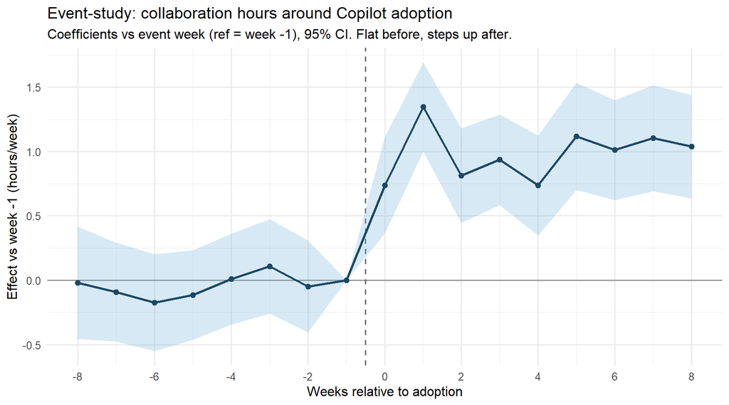

```r
es <- fixest::feols(
  Collaboration_hours ~ i(event_week, treated_grp, ref = -1) |
    PersonId + MetricDate,
  data    = panel_es,
  cluster = ~PersonId
)

# Tidy the event-time coefficients for a ggplot
es_tab <- as.data.frame(coeftable(es))
es_tab$term <- rownames(es_tab)
es_coefs <- es_tab %>%
  filter(grepl("event_week::", term)) %>%
  mutate(
    event_week = as.integer(sub(".*event_week::(-?\\d+).*", "\\1", term)),
    lwr = Estimate - 1.96 * `Std. Error`,
    upr = Estimate + 1.96 * `Std. Error`
  )

# Add the reference week (-1) at exactly 0
es_coefs <- bind_rows(
  es_coefs,
  tibble(event_week = -1, Estimate = 0, lwr = 0, upr = 0)
) %>% arrange(event_week)

ggplot(es_coefs, aes(event_week, Estimate)) +
  geom_hline(yintercept = 0, colour = "grey60") +
  geom_vline(xintercept = -0.5, linetype = "dashed", colour = "grey40") +
  geom_ribbon(aes(ymin = lwr, ymax = upr), fill = "#5fa8d3", alpha = 0.25) +
  geom_line(linewidth = 1, colour = "#1b4965") +
  geom_point(size = 2, colour = "#1b4965") +
  scale_x_continuous(breaks = seq(-WINDOW, WINDOW, 2)) +
  labs(
    title    = "Event-study: collaboration hours around Copilot adoption",
    subtitle = "Coefficients vs event week (ref = week -1), 95% CI. Flat before, steps up after.",
    x = "Weeks relative to adoption", y = "Effect vs week -1 (hours/week)"
  ) +
  theme_minimal(base_size = 12)
```

A flat pre-period and a clean post-period step is the visual signature of a credible DiD. If the pre-period coefficients trended, you would be worried that adopters were already diverging before Copilot and would treat the DiD estimate with caution.

## Bonus: run the same design on a composite index

Individual metrics can be noisy. A robust alternative is to combine several related collaboration metrics into a single **z-scored composite index**, then run the identical DiD on the index. Each component is standardised across the panel (mean 0, sd 1) and averaged, so no single metric’s scale dominates.

```r
components <- c("Collaboration_hours", "Chat_hours", "Emails_sent")

zscore <- function(x) (x - mean(x, na.rm = TRUE)) / sd(x, na.rm = TRUE)

panel_es <- panel_es %>%
  mutate(across(all_of(components), zscore, .names = "z_{.col}")) %>%
  mutate(collab_index = rowMeans(across(starts_with("z_")), na.rm = TRUE))

did_index <- fixest::feols(
  collab_index ~ treat_post | PersonId + MetricDate,
  data    = panel_es,
  cluster = ~PersonId
)

summary(did_index)
```

```
## OLS estimation, Dep. Var.: collab_index
## Observations: 6,800
## Fixed-effects: PersonId: 400,  MetricDate: 35
## Standard-errors: Clustered (PersonId)
##            Estimate Std. Error t value  Pr(>|t|)
## treat_post 0.217774   0.025462  8.5528 2.603e-16 ***
## ---
## Signif. codes:  0 '***' 0.001 '**' 0.01 '*' 0.05 '.' 0.1 ' ' 1
## RMSE: 0.51072     Adj. R2: 0.669367
##                 Within R2: 0.011784
```

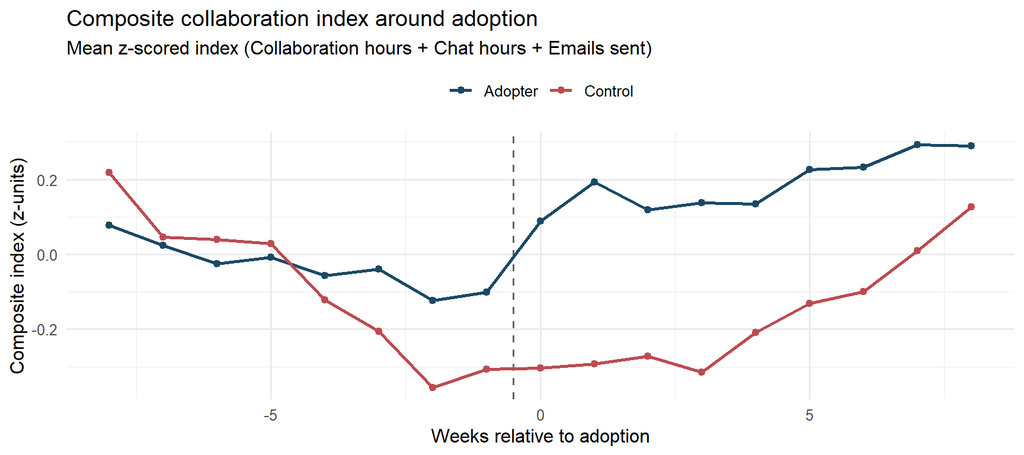

```r
# Event-time trajectory of the composite, treated vs control
idx_traj <- panel_es %>%
  mutate(grp = ifelse(treated_grp == 1, "Adopter", "Control")) %>%
  group_by(grp, event_week) %>%
  summarise(idx = mean(collab_index), .groups = "drop")

ggplot(idx_traj, aes(event_week, idx, colour = grp)) +
  geom_vline(xintercept = -0.5, linetype = "dashed", colour = "grey40") +
  geom_line(linewidth = 1) +
  geom_point(size = 1.8) +
  scale_colour_manual(values = c("Adopter" = "#1b4965", "Control" = "#bc4b51"),
                      name = NULL) +
  labs(
    title    = "Composite collaboration index around adoption",
    subtitle = "Mean z-scored index (Collaboration hours + Chat hours + Emails sent)",
    x = "Weeks relative to adoption", y = "Composite index (z-units)"
  ) +
  theme_minimal(base_size = 12) +
  theme(legend.position = "top")
```

## Wrapping up

The event-study + TWFE DiD pattern is a portable way to ask *“did behaviour change after adoption, within the same person?”* without being fooled by the fact that adopters differ from non-adopters. To apply it to your own data, replace the simulation chunk with `vivainsights::import_query()`, derive the adoption week from the first non-zero Copilot action, set `TREATMENT_EFFECT` aside entirely, and let the model estimate the effect. Always inspect the event-study pre-trends before trusting the single DiD number.